# KP Lung CD8 T-Cell 10X 5’ Immune Profiling Pre-Processing

```r
library(Seurat)
library(dplyr)
library(patchwork)
library(ggplot2)
#library(future)
```

Set up output directory:

```r
od <- paste0("/Users/amandacruz/Dropbox (MIT)/SIIN vs SIY 10X/Final_Analysis/",Sys.Date(),"/") # this is where the output directory setup will be made
dir.create(od) # run this line if you havent already made the output directory folder
```

Set input file paths and day code is executed. (Day will be appended to the beginning of all output files, for clarity)

```r
day <- paste0(Sys.Date(),"_") # this will automatically detect the date you are running the code

siy.path <- "/Users/amandacruz/Dropbox (MIT)/SIIN vs SIY 10X/Seurat/Data/raw_siy_filteredbcmatrix"
siin.path <- "/Users/amandacruz/Dropbox (MIT)/SIIN vs SIY 10X/Seurat/Data/raw_siin_filteredbcmatrix"

antigens <- c("siin", "siy")
an_colors = c(siin = "#F8766D",siy = "#00BFC4")
```

### Create Seurat Objects

```r
# Load Data
siy.data <- Read10X(data.dir = siy.path)
siin.data <- Read10X(data.dir = siin.path)

# Create Seurat Objects
siin <- CreateSeuratObject(counts = siin.data, project = "siin", min.cells = 3, min.features = 5)
siy <- CreateSeuratObject(counts = siy.data, project = "siy", min.cells = 3, min.features = 5)
```

### Individual Library QC Metrics

This will calculate various QC metrics for each library individually. This information is utilized to compare the differences between each library.

```r
# define output subdirectory
dir.create(paste0(od,"Pre-QC/"))
dir.create(paste0(od,"Pre-QC/Individual_libraries/"))
od.qc.indiv <- paste0(od,"Pre-QC/Individual_libraries/")

# quantify mitochondrial genes
siin[["percent.mt"]] <- PercentageFeatureSet(siin, pattern = "^mt-")
siy[["percent.mt"]] <- PercentageFeatureSet(siy, pattern = "^mt-")
```

Plot:

```r
# violin plots of QC metrics
qc.indiv.vp <- list()

qc.indiv.vp[[1]] <- VlnPlot(siin, features = c("nFeature_RNA", "nCount_RNA", "percent.mt"), ncol = 3, pt.size = 0.25, cols = an_colors[1])
qc.indiv.vp[[2]] <- VlnPlot(siy, features = c("nFeature_RNA", "nCount_RNA", "percent.mt"), ncol = 3, pt.size = 0.25, cols = an_colors[2])

# scatter plots of features
qc.indiv.sp <- list()
qc.indiv.sp[[1]] <- FeatureScatter(siin, feature1 = "nCount_RNA", feature2 = "nFeature_RNA", cols = an_colors[1]) + ggtitle("Reads vs Genes Detected")
qc.indiv.sp[[2]] <- FeatureScatter(siy, feature1 = "nCount_RNA", feature2 = "nFeature_RNA", cols = an_colors[2]) + ggtitle("Reads vs Genes Detected")

# save plots
pdf(file=paste0(od.qc.indiv, day, "individual_qc_violinPlots.pdf"), height = 14, width = 9)
wrap_plots(qc.indiv.vp, ncol = 1, nrow = 2)
dev.off()
```

```r
pdf(file=paste0(od.qc.indiv, day, "individual_qc_scatterPlots_counts-vs-genes.pdf"), height = 14, width = 9)
```

[figure not shown]

```r
wrap_plots(qc.indiv.sp, ncol = 1, nrow = 2)
```

```r
dev.off()
```

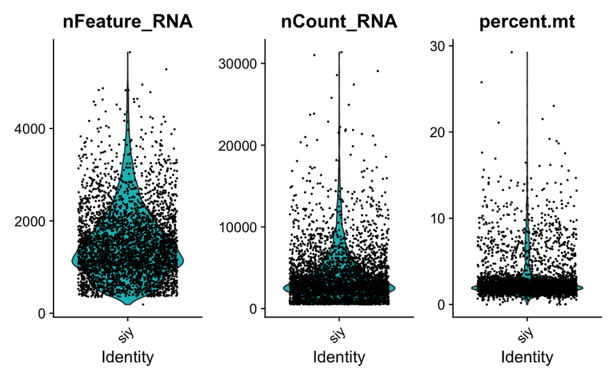

```r
# visualize plots
qc.indiv.vp
```

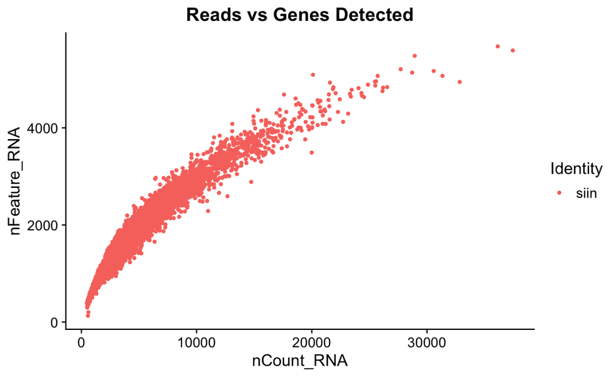

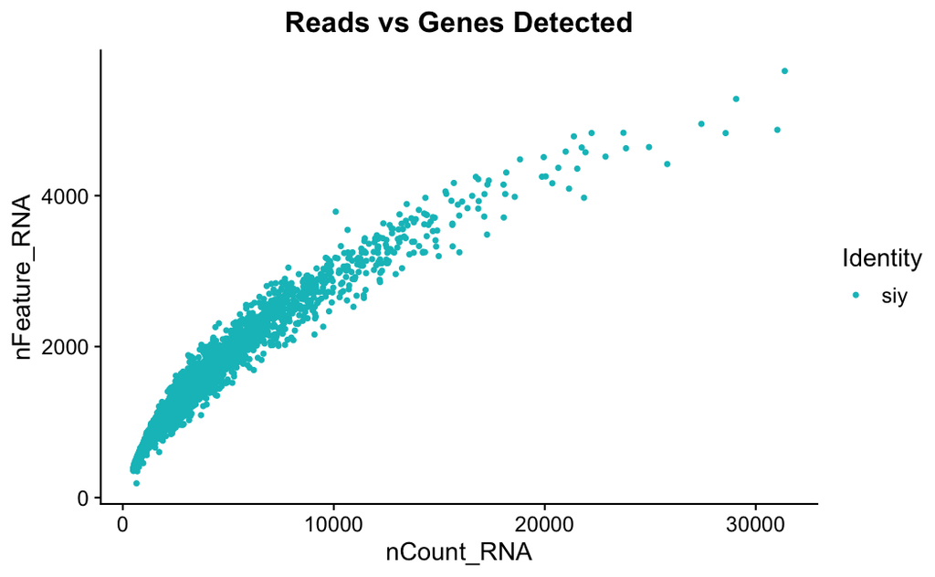

```r
qc.indiv.sp
```

```r
# filter out cells that do not pass QC thresholds
siin <- subset(siin, subset = nFeature_RNA > 100 & nFeature_RNA < 4000 & percent.mt < 5 & nCount_RNA < 20000)
siy <- subset(siy, subset = nFeature_RNA > 100 & nFeature_RNA < 4000 & percent.mt < 5 & nCount_RNA < 20000)
```

Follow this code for standard normalization + merging: ###### Normalization

```r
## normalize data ##
siin <- NormalizeData(siin, normalization.method = "LogNormalize", scale.factor = 10000, vars.to.regress = "percent.mt")
```

```
The following arguments are not used: vars.to.regressPerforming log-normalization
```

```r
siy <- NormalizeData(siy, normalization.method = "LogNormalize", scale.factor = 10000, vars.to.regress = "percent.mt")
```

```
The following arguments are not used: vars.to.regressPerforming log-normalization
```

```r
# scale
#siin <- ScaleData(siin, vars.to.regress = "percent.mt")
#siy <- ScaleData(siy, vars.to.regress = "percent.mt")

## variable feature detection ##
siin <- FindVariableFeatures(siin, selection.method = "vst", nfeatures = 2000)
siy <- FindVariableFeatures(siy, selection.method = "vst", nfeatures = 2000)
top10.siin <- head(VariableFeatures(siin), 10)
top10.siy <- head(VariableFeatures(siy), 10)


# plot variable features with and without labels
vfp <- VariableFeaturePlot(siin)
vfp.l <- LabelPoints(plot = vfp, points = top10.siin, repel = TRUE)
```

```
When using repel, set xnudge and ynudge to 0 for optimal results
```

```r
pdf(file=paste0(od.qc.indiv,day,"siin_variablegenes.pdf"),width=9,height=7)
vfp + vfp.l
dev.off()
```

```r
vfp2 <- VariableFeaturePlot(siy)
vfp2.l <- LabelPoints(plot = vfp2, points = top10.siy, repel = TRUE)
```

```
When using repel, set xnudge and ynudge to 0 for optimal results
```

```r
pdf(file=paste0(od.qc.indiv,day,"siy_variablegenes.pdf"),width=9,height=7)
```

```r
vfp2 + vfp2.l
dev.off()
```

### Merge Datasets

```r
# combine into one seurat object
siin <- ScaleData(siin, vars.to.regress = "percent.mt")
siy <- ScaleData(siy, vars.to.regress = "percent.mt")
cd8 <- merge(siin, y = siy, add.cell.ids = c("siin", "siy"), project = "kplung_cd8", merge.data = TRUE)

# clear memory
rm(siin.data, siy.data)
```

Plot QC metrics post filtering:

```r
# output subdirectory
dir.create(paste0(od,"Post-QC/"))
dir.create(paste0(od,"Post-QC/merged/"))
od.qc.m <- paste0(od,"Post-QC/merged/")

# save file
pdf(file=paste0(od.qc.m,day,"merge_postQC_violin.pdf"),width=9,height=7)
VlnPlot(cd8, features = c("nFeature_RNA", "nCount_RNA", "percent.mt"), ncol = 3, pt.size=0.25)
dev.off()
```

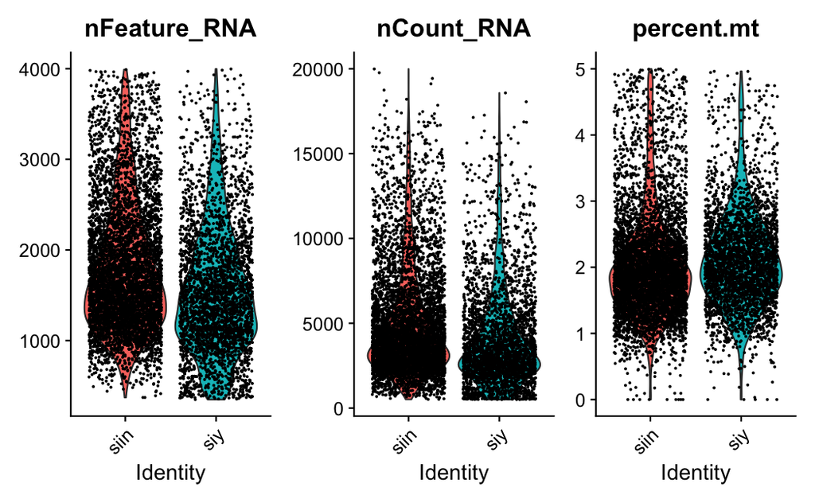

```r
# visualize in notebook
VlnPlot(cd8, features = c("nFeature_RNA", "nCount_RNA", "percent.mt"), ncol = 3, pt.size=0.25)
```

#### Add in VDJ & Hashing Data

At this point, as part of the QC filtering, we would like to filter out empirically determined doublets. These doublets are detected using TotalSeqC antibody hashing. The premise is that cells with a hashing ID that come from more than one mouse are likely doublets. This processing uses a combination of Python and R, broken up in multiple notebooks.

Export cell IDs to CSV:

```r
dir.create(paste0(od,"Metadata/"))
```

```
'/Users/amandacruz/Dropbox (MIT)/SIIN vs SIY 10X/Final_Analysis/2020-11-03/Metadata' already exists
```

```r
od.md <- paste0(od,"Metadata/")
write.csv(cd8@meta.data, file = paste0(od.md,day,"md_prefilter.csv"))
```

At this point, we will use python to fill in information about cells to add to the metadata, add in VDJ information, and add in Hashing. The Hashing analysis/processing is covered in a separate notebook.

###### Load metadata:

```r
md <- read.csv(file = paste0(od.md, day, "md_posthash.csv"))
cd8[['demux']] = md[['demux']]
md[['top_clonotypes']] = factor(md[['top_clonotypes']])
cd8 = RenameCells(cd8, new.names = md[['barcode']])
```

#### Remove Doublets

```r
cd8 = SetIdent(cd8, value='demux')
not_doublets <- WhichCells(object = cd8, idents = 'Doublet', invert = TRUE)
cd8 <- cd8[,not_doublets]
```

```r
write.csv(cd8@meta.data,paste0(od.md,day,"md_doublets_out.csv"))
```

Load in final metadata:

```r
md <- read.csv(file = paste0(od.md, day, "md_final.csv"))
md = data.frame(md)

# add as metadata; this was glitchy so its not done in a standard way
for (i in colnames(md)) {
  cd8[[i]] = md[[i]]
}
```

#### Save PreProcessed Seurat Object

```r
saveRDS(cd8,paste0(od,day,"preprocessed_norm_seurat.rds"))
```

```r
all.genes <- rownames(cd8)
cd8 <- FindVariableFeatures(cd8, selection.method = "vst", nfeatures = 2000)
cd8 <- ScaleData(cd8, features = all.genes)
#cd8 <- SCTransform(cd8, vars.to.regress = "percent.mt", verbose = T, min_cells = 3)
```

Load in final metadata:

```r
md <- read.csv(file = paste0(od.md, day, "md_final.csv"))
md = data.frame(md)

# add as metadata; this was glitchy so its not done in a standard way
for (i in colnames(md)) {
  cd8[[i]] = md[[i]]
}
```

# Dimensionality Reduction

###### Preprocessing PCA

```r
cd8 <- RunPCA(cd8,  features = VariableFeatures(object = cd8))
```

```
PC_ 1
Positive:  Lag3, Ucp2, Pdcd1, Tmsb4x, Cd52, Nkg7, Cd3d, Sh2d2a, Shisa5, Lsp1
       Cst7, Tigit, Limd2, Gmfg, Rgs16, Actb, Il2rb, Ptprcap, Pglyrp1, Rac2
       Itgb2, Pfn1, Arpc1b, Tnfrsf9, Ptms, Igfbp7, Ifi27l2a, Coro1a, Ctsb, Ifng
Negative:  Bcl2, Atf5, Slc7a5, Bbc3, Cdkn1a, Snhg12, Hspa9, Trib3, Lgals3, Ddit3
       Pim1, Cebpb, Ahnak, Slc3a2, Aars, Socs2, 2810474O19Rik, Ifitm1, Ndrg1, Epb41l4aos
       Pim2, Npm1, Hist3h2ba, Eprs, Neat1, Hist1h3e, Rps20, Lmna, Qpct, Rps2
PC_ 2
Positive:  Tnfrsf4, Cd83, Xcl1, Il1r2, Egr2, Zfp36l1, Ccl1, Tnfsf8, Tnfrsf9, Igfbp7
       Ramp1, Bdh2, Nr4a1, Ccr6, Hspa9, Cd81, Rgs16, Cd200, Eea1, Dusp4
       1700019D03Rik, Rps2, Nr4a3, Nrgn, Cdkn1a, Nfkbia, Tbc1d4, Prelid2, Relb, Crtam
Negative:  Ccl5, Ctla2a, S100a6, Vim, Cxcr6, Cd52, Ctsd, Nkg7, Ms4a4b, Zyx
       Crip1, Trgv2, Tmsb4x, Ctsw, Epsti1, Sema4a, Hcst, Lgals1, Fgl2, AW112010
       Gzmk, Ccr5, Coro1a, Sh3bgrl3, Actb, Glrx, Tagln2, Pglyrp2, Rac2, Shisa5
PC_ 3
Positive:  Pclaf, Birc5, Ccna2, Spc24, Stmn1, Cdca3, Rrm2, Ccnb2, Ube2c, Cks1b
       Nusap1, Aurkb, Fbxo5, Ckap2l, Tpx2, Mki67, Knl1, Cdca5, Cenpf, Cenpe
       Top2a, Hmmr, Cdca8, Tcf19, Kif22, Rad51ap1, Asf1b, Gm4316, Kif11, Cdk1
Negative:  Ramp1, Shisa5, Icos, Rgs10, Cxcr6, Cd82, Tmem176a, Itm2c, Lag3, Il1r2
       Igfbp7, Zfp36l1, Csf1, Maf, Rorc, Tmem176b, Sdc4, Cd81, Slfn2, Ucp2
       Il2rg, Egr2, Ccr6, Cd52, Tbc1d4, Itgb7, Ctla4, Cd84, Ctsw, Timp2
PC_ 4
Positive:  Ramp1, Tmem176a, Tmem176b, Itgb7, Rorc, Il1r2, Maf, Sdc4, Cd81, Aqp3
       Vax2, Podnl1, Ccna2, Emb, Tnfrsf25, Igfbp7, 1700012B07Rik, Pclaf, Birc5, Il17a
       Gpr25, Rgs10, Spc24, Mast4, Ccr6, Ablim3, Ccr4, Rrm2, Runx1, Ly6e
Negative:  Rps15a, Rpl32, Rps12, Rpl35, Rplp0, Rpl41, Rps20, Rps26, Rps18, Rpl15
       Rpl28, Rps2, Rpl10a, Rpl7a, Rpl3, Rpl29, Npm1, Rpl22l1, Hspe1, Rps17
       Klrc1, Ccl4, Ccl3, Irf8, Rpl31, Tnfrsf9, Rgs16, Eif2s2, Rbm3, Myl12a
PC_ 5
Positive:  Tmsb10, Rpl41, Rplp0, Tcf7, Rps20, Rpl32, Rps26, Rpl35, Rpl29, Rps15a
       Rpl3, Rps18, Rpl10a, Rps12, Rpl15, Rgs10, Rps2, Rpl28, Ly6e, Ppia
       Evl, Slamf6, Ccr6, Tmsb4x, Il7r, Emb, Itgb7, Rpl7a, Dapl1, Ndufa4
Negative:  Ccl3, Ccl4, Havcr2, Ifng, Rgs16, Tnfrsf9, Prf1, Ahnak, Nr4a3, Ccl1
       Nr4a2, Irf8, Plek, Klrc1, Nkg7, Il2ra, Egr2, Mir155hg, Atf3, Nr4a1
       Tigit, Nfkbid, Il21r, Entpd1, Klrd1, Csf1, Gpr65, Cdk6, Egr3, Adgrg1
```

###### PCA Outputs

Set outputs:

```r
dir.create(paste0(od,"dimensionality_reduction/"))
od.dr <- paste0(od,"dimensionality_reduction/")
```

```r
# plot first couple PCs and visualize dimensions
pdf(file=paste0(od.dr,day,"merge_PCA1.pdf"), width=9, height=7)
DimPlot(cd8, reduction = "pca")
dev.off()
```

```r
pdf(file=paste0(od.dr,day,"PCA1_heatmap.pdf"), width=9, height=7)
```

```r
DimHeatmap(cd8, dims = 1, cells = 500, balanced = TRUE)
dev.off()
```

```r
pdf(file=paste0(od.dr,day,"PCAplus_heatmap.pdf"), width=9, height=7)
```

```r
DimHeatmap(cd8, dims = 1:5, cells = 500, balanced = TRUE)
dev.off()
```

```r
# plot PCs in the upper range of the predicted # of PCs by JackStraw/Elbow plots for downstream dimensionality reductions
pdf(file=paste0(od.dr,day,"PCA25-35_heatmap.pdf"), width=9, height=7)
```

```r
DimHeatmap(cd8, dims = 25:35, cells = 500, balanced = TRUE)
dev.off()
```

###### Clustering & UMAP

```r
cd8 <- FindNeighbors(cd8, dims = 1:30)
```

```r
cd8 <- FindClusters(cd8, resolution = 0.7)
```

```
Modularity Optimizer version 1.3.0 by Ludo Waltman and Nees Jan van Eck

Number of nodes: 5884
Number of edges: 213965

Running Louvain algorithm...
```

```
Maximum modularity in 10 random starts: 0.7717
Number of communities: 11
Elapsed time: 0 seconds
```

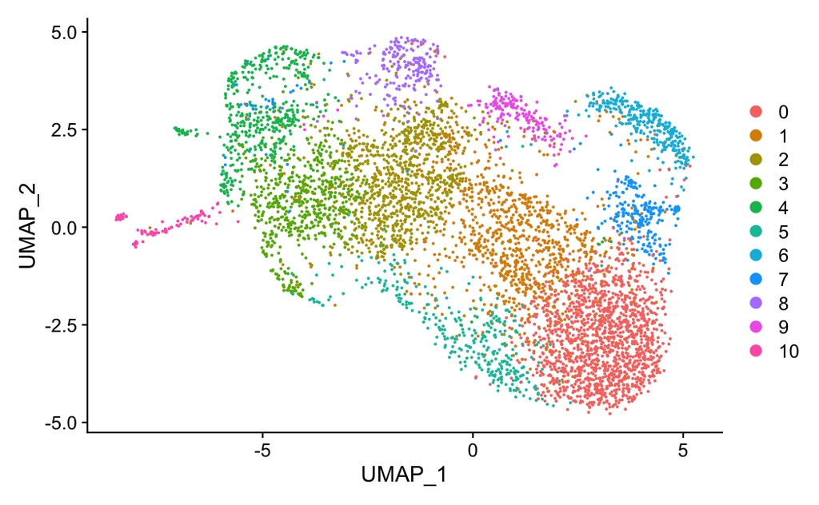

```r
cd8 <- RunUMAP(cd8, dims = 1:30, seed.use = 42)
DimPlot(cd8, reduction = "umap")
```